# Project: Identify Customer Segments

In this project, I will apply unsupervised learning techniques to identify segments of the population that form the core customer base for a mail-order sales company in Germany. These segments can then be used to direct marketing campaigns towards audiences that will have the highest expected rate of returns. The data that I will use has been provided by our partners at Bertelsmann Arvato Analytics, and represents a real-life data science task.

```python
import numpy as np
import pandas as pd
import matplotlib.pyplot as plt
import seaborn as sns

# magic word for producing visualizations in notebook
%config InlineBackend.figure_format='retina'
%matplotlib inline
```

### Step 0: Load the Data

Each row of the demographics files represents a single person, but also includes information outside of individuals, including information about their household, building, and neighborhood. I will use this information to cluster the general population into groups with similar demographic properties. Then, I will see how the people in the customers dataset fit into those created clusters. The hope here is that certain clusters are over-represented in the customers data, as compared to the general population; those over-represented clusters will be assumed to be part of the core userbase. This information can then be used for further applications, such as targeting for a marketing campaign.

To start off with, I'll load in the demographics data for the general population into a pandas DataFrame, and do the same for the feature attributes summary.

```python
# Load in the general demographics data.
azdias = pd.read_csv("Udacity_AZDIAS_Subset.csv",sep=";")

# Load in the feature summary file.
feat_info = pd.read_csv("AZDIAS_Feature_Summary.csv",sep=";")
```

```python
# Check the structure of the data after it's loaded
print(f"AZDIAS dataset contains {azdias.shape[0]} rows, and {azdias.shape[1]} columns.")
print(f"Feature summary dataset contains {feat_info.shape[0]} rows, and {feat_info.shape[1]} columns.")
```

```
AZDIAS dataset contains 891221 rows, and 85 columns.
Feature summary dataset contains 85 rows, and 4 columns.
```

```python
azdias.head()
```

|  | AGER_TYP | ALTERSKATEGORIE_GROB | ANREDE_KZ | CJT_GESAMTTYP | FINANZ_MINIMALIST | FINANZ_SPARER | FINANZ_VORSORGER | FINANZ_ANLEGER | FINANZ_UNAUFFAELLIGER | FINANZ_HAUSBAUER | ... | PLZ8_ANTG1 | PLZ8_ANTG2 | PLZ8_ANTG3 | PLZ8_ANTG4 | PLZ8_BAUMAX | PLZ8_HHZ | PLZ8_GBZ | ARBEIT | ORTSGR_KLS9 | RELAT_AB |
| --- | --- | --- | --- | --- | --- | --- | --- | --- | --- | --- | --- | --- | --- | --- | --- | --- | --- | --- | --- | --- | --- |
| 0 | -1 | 2 | 1 | 2.0 | 3 | 4 | 3 | 5 | 5 | 3 | ... | NaN | NaN | NaN | NaN | NaN | NaN | NaN | NaN | NaN | NaN |
| 1 | -1 | 1 | 2 | 5.0 | 1 | 5 | 2 | 5 | 4 | 5 | ... | 2.0 | 3.0 | 2.0 | 1.0 | 1.0 | 5.0 | 4.0 | 3.0 | 5.0 | 4.0 |
| 2 | -1 | 3 | 2 | 3.0 | 1 | 4 | 1 | 2 | 3 | 5 | ... | 3.0 | 3.0 | 1.0 | 0.0 | 1.0 | 4.0 | 4.0 | 3.0 | 5.0 | 2.0 |
| 3 | 2 | 4 | 2 | 2.0 | 4 | 2 | 5 | 2 | 1 | 2 | ... | 2.0 | 2.0 | 2.0 | 0.0 | 1.0 | 3.0 | 4.0 | 2.0 | 3.0 | 3.0 |
| 4 | -1 | 3 | 1 | 5.0 | 4 | 3 | 4 | 1 | 3 | 2 | ... | 2.0 | 4.0 | 2.0 | 1.0 | 2.0 | 3.0 | 3.0 | 4.0 | 6.0 | 5.0 |

5 rows × 85 columns

```python
azdias.describe()
```

|  | AGER_TYP | ALTERSKATEGORIE_GROB | ANREDE_KZ | CJT_GESAMTTYP | FINANZ_MINIMALIST | FINANZ_SPARER | FINANZ_VORSORGER | FINANZ_ANLEGER | FINANZ_UNAUFFAELLIGER | FINANZ_HAUSBAUER | ... | PLZ8_ANTG1 | PLZ8_ANTG2 | PLZ8_ANTG3 | PLZ8_ANTG4 | PLZ8_BAUMAX | PLZ8_HHZ | PLZ8_GBZ | ARBEIT | ORTSGR_KLS9 | RELAT_AB |
| --- | --- | --- | --- | --- | --- | --- | --- | --- | --- | --- | --- | --- | --- | --- | --- | --- | --- | --- | --- | --- | --- |
| count | 891221.000000 | 891221.000000 | 891221.000000 | 886367.000000 | 891221.000000 | 891221.000000 | 891221.000000 | 891221.000000 | 891221.000000 | 891221.000000 | ... | 774706.000000 | 774706.000000 | 774706.000000 | 774706.000000 | 774706.000000 | 774706.000000 | 774706.000000 | 794005.000000 | 794005.000000 | 794005.00000 |
| mean | -0.358435 | 2.777398 | 1.522098 | 3.632838 | 3.074528 | 2.821039 | 3.401106 | 3.033328 | 2.874167 | 3.075121 | ... | 2.253330 | 2.801858 | 1.595426 | 0.699166 | 1.943913 | 3.612821 | 3.381087 | 3.167854 | 5.293002 | 3.07222 |
| std | 1.198724 | 1.068775 | 0.499512 | 1.595021 | 1.321055 | 1.464749 | 1.322134 | 1.529603 | 1.486731 | 1.353248 | ... | 0.972008 | 0.920309 | 0.986736 | 0.727137 | 1.459654 | 0.973967 | 1.111598 | 1.002376 | 2.303739 | 1.36298 |
| min | -1.000000 | 1.000000 | 1.000000 | 1.000000 | 1.000000 | 1.000000 | 1.000000 | 1.000000 | 1.000000 | 1.000000 | ... | 0.000000 | 0.000000 | 0.000000 | 0.000000 | 1.000000 | 1.000000 | 1.000000 | 1.000000 | 0.000000 | 1.00000 |
| 25% | -1.000000 | 2.000000 | 1.000000 | 2.000000 | 2.000000 | 1.000000 | 3.000000 | 2.000000 | 2.000000 | 2.000000 | ... | 1.000000 | 2.000000 | 1.000000 | 0.000000 | 1.000000 | 3.000000 | 3.000000 | 3.000000 | 4.000000 | 2.00000 |
| 50% | -1.000000 | 3.000000 | 2.000000 | 4.000000 | 3.000000 | 3.000000 | 3.000000 | 3.000000 | 3.000000 | 3.000000 | ... | 2.000000 | 3.000000 | 2.000000 | 1.000000 | 1.000000 | 4.000000 | 3.000000 | 3.000000 | 5.000000 | 3.00000 |
| 75% | -1.000000 | 4.000000 | 2.000000 | 5.000000 | 4.000000 | 4.000000 | 5.000000 | 5.000000 | 4.000000 | 4.000000 | ... | 3.000000 | 3.000000 | 2.000000 | 1.000000 | 3.000000 | 4.000000 | 4.000000 | 4.000000 | 7.000000 | 4.00000 |
| max | 3.000000 | 9.000000 | 2.000000 | 6.000000 | 5.000000 | 5.000000 | 5.000000 | 5.000000 | 5.000000 | 5.000000 | ... | 4.000000 | 4.000000 | 3.000000 | 2.000000 | 5.000000 | 5.000000 | 5.000000 | 9.000000 | 9.000000 | 9.00000 |

8 rows × 81 columns

```python
azdias.info()
```

```
<class 'pandas.core.frame.DataFrame'>
RangeIndex: 891221 entries, 0 to 891220
Data columns (total 85 columns):
 #   Column                 Non-Null Count   Dtype
---  ------                 --------------   -----
 0   AGER_TYP               891221 non-null  int64
 1   ALTERSKATEGORIE_GROB   891221 non-null  int64
 2   ANREDE_KZ              891221 non-null  int64
 3   CJT_GESAMTTYP          886367 non-null  float64
 4   FINANZ_MINIMALIST      891221 non-null  int64
 5   FINANZ_SPARER          891221 non-null  int64
 6   FINANZ_VORSORGER       891221 non-null  int64
 7   FINANZ_ANLEGER         891221 non-null  int64
 8   FINANZ_UNAUFFAELLIGER  891221 non-null  int64
 9   FINANZ_HAUSBAUER       891221 non-null  int64
```

[output cut: 77 more lines]

```python
feat_info.head()
```

|  | attribute | information_level | type | missing_or_unknown |
| --- | --- | --- | --- | --- |
| 0 | AGER_TYP | person | categorical | [-1,0] |
| 1 | ALTERSKATEGORIE_GROB | person | ordinal | [-1,0,9] |
| 2 | ANREDE_KZ | person | categorical | [-1,0] |
| 3 | CJT_GESAMTTYP | person | categorical | [0] |
| 4 | FINANZ_MINIMALIST | person | ordinal | [-1] |

```python
feat_info.describe()
```

|  | attribute | information_level | type | missing_or_unknown |
| --- | --- | --- | --- | --- |
| count | 85 | 85 | 85 | 85 |
| unique | 85 | 9 | 5 | 9 |
| top | AGER_TYP | person | ordinal | [-1] |
| freq | 1 | 43 | 49 | 26 |

```python
feat_info.info()
```

```
<class 'pandas.core.frame.DataFrame'>
RangeIndex: 85 entries, 0 to 84
Data columns (total 4 columns):
 #   Column              Non-Null Count  Dtype
---  ------              --------------  -----
 0   attribute           85 non-null     object
 1   information_level   85 non-null     object
 2   type                85 non-null     object
 3   missing_or_unknown  85 non-null     object
dtypes: object(4)
memory usage: 2.8+ KB
```

## Step 1: Preprocessing

### Step 1.1: Assess Missing Data

The feature summary file contains a summary of properties for each demographics data column. I will use this file to help me make cleaning decisions during this stage of the project. First of all, I should assess the demographics data in terms of missing data.

#### Step 1.1.1: Convert Missing Value Codes to NaNs

The fourth column of the feature attributes summary (loaded in above as `feat_info`) documents the codes from the data dictionary that indicate missing or unknown data. While the file encodes this as a list (e.g. `[-1,0]`), this will get read in as a string object. I'll need to do a little bit of parsing to make use of it to identify and clean the data. Convert data that matches a 'missing' or 'unknown' value code into a numpy NaN value. I might want to see how much data takes on a 'missing' or 'unknown' code, and how much data is naturally missing, as a point of interest.

```python
# assess number of NaN values before using feat_info dataset
azdias.isna().sum().sum()
```

```
4896838
```

```python
# identify values in the missing_or_unknown column
feat_info.missing_or_unknown.value_counts()
```

```
missing_or_unknown
[-1]        26
[-1,9]      17
[-1,0]      16
[0]         12
[]          10
[-1,0,9]     1
[-1,X]       1
[XX]         1
[-1,XX]      1
Name: count, dtype: int64
```

```python
# create a new column in feat_info without the square brackets
# implementing it in the following for loop would result in too many fuction calls which isn't efficient
feat_info["missing_or_unknown2"] = feat_info.missing_or_unknown.str.replace("[","").str.replace("]","")
```

```python
for column in range(azdias.shape[1]):
    missing_list = feat_info.iloc[column,4].split(",")
    missing_list = [int(val) if (val != '' and val != 'X' and val != 'XX') else val for val in missing_list]
    if missing_list != ['']:
        azdias = azdias.replace({feat_info.iloc[column]['attribute']: missing_list}, np.nan)
```

```python
# assess number of NaN values after using feat_info dataset
azdias.isna().sum().sum()
```

```
8373929
```

#### Step 1.1.2: Assess Missing Data in Each Column

How much missing data is present in each column? There are a few columns that are outliers in terms of the proportion of values that are missing.

```python
# Perform an assessment of how much missing data there is in each column of the dataset.
azdias.isna().sum().sort_values(ascending=False)
```

```
TITEL_KZ        889061
AGER_TYP        685843
KK_KUNDENTYP    584612
KBA05_BAUMAX    476524
GEBURTSJAHR     392318
                 ...
SEMIO_RAT            0
SEMIO_KRIT           0
SEMIO_DOM            0
SEMIO_TRADV          0
ZABEOTYP             0
Length: 85, dtype: int64
```

```python
percentage_missing = azdias.isna().mean().sort_values(ascending=False)*100
percentage_missing
```

```
TITEL_KZ        99.757636
AGER_TYP        76.955435
KK_KUNDENTYP    65.596749
KBA05_BAUMAX    53.468668
GEBURTSJAHR     44.020282
                  ...
SEMIO_RAT        0.000000
SEMIO_KRIT       0.000000
SEMIO_DOM        0.000000
SEMIO_TRADV      0.000000
ZABEOTYP         0.000000
Length: 85, dtype: float64
```

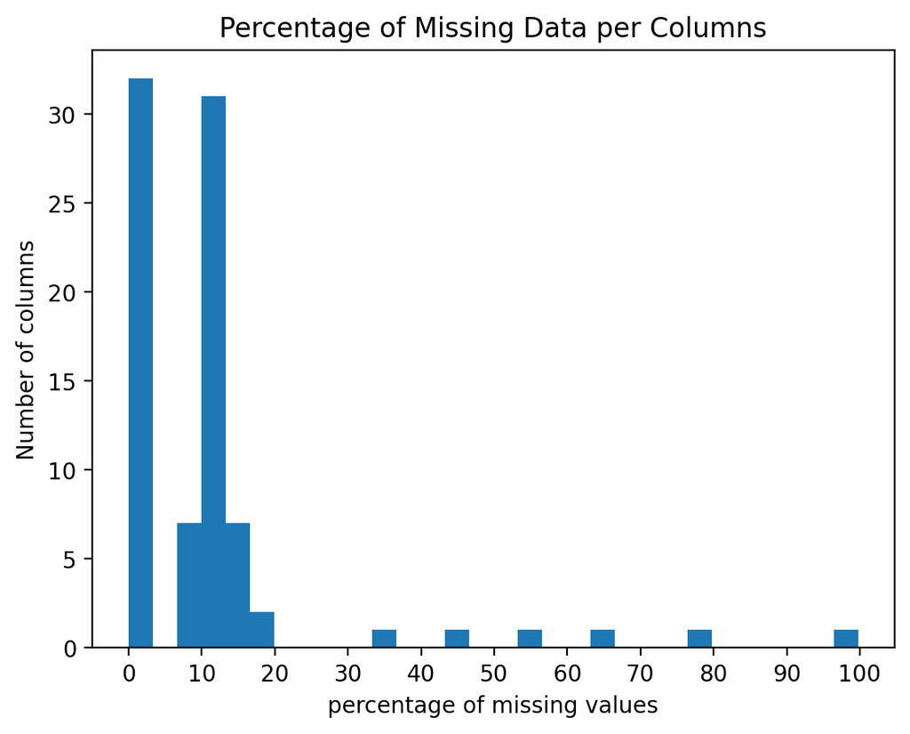

```python
# Investigate patterns in the amount of missing data in each column.
# plot the previous numbers to assess them better
plt.hist(percentage_missing, bins=30)
plt.title("Percentage of Missing Data per Columns")
plt.xlabel("percentage of missing values")
plt.ylabel("Number of columns")
plt.xticks(np.arange(0,101,10));
```

```python
# Remove the outlier columns from the dataset.
col_threshold = 20
cols_over_threshold = percentage_missing[percentage_missing > col_threshold]
azdias_clean = azdias.drop(cols_over_threshold.index, axis=1)
azdias_clean.head()
```

|  | ALTERSKATEGORIE_GROB | ANREDE_KZ | CJT_GESAMTTYP | FINANZ_MINIMALIST | FINANZ_SPARER | FINANZ_VORSORGER | FINANZ_ANLEGER | FINANZ_UNAUFFAELLIGER | FINANZ_HAUSBAUER | FINANZTYP | ... | PLZ8_ANTG1 | PLZ8_ANTG2 | PLZ8_ANTG3 | PLZ8_ANTG4 | PLZ8_BAUMAX | PLZ8_HHZ | PLZ8_GBZ | ARBEIT | ORTSGR_KLS9 | RELAT_AB |
| --- | --- | --- | --- | --- | --- | --- | --- | --- | --- | --- | --- | --- | --- | --- | --- | --- | --- | --- | --- | --- | --- |
| 0 | 2.0 | 1 | 2.0 | 3 | 4 | 3 | 5 | 5 | 3 | 4 | ... | NaN | NaN | NaN | NaN | NaN | NaN | NaN | NaN | NaN | NaN |
| 1 | 1.0 | 2 | 5.0 | 1 | 5 | 2 | 5 | 4 | 5 | 1 | ... | 2.0 | 3.0 | 2.0 | 1.0 | 1.0 | 5.0 | 4.0 | 3.0 | 5.0 | 4.0 |
| 2 | 3.0 | 2 | 3.0 | 1 | 4 | 1 | 2 | 3 | 5 | 1 | ... | 3.0 | 3.0 | 1.0 | 0.0 | 1.0 | 4.0 | 4.0 | 3.0 | 5.0 | 2.0 |
| 3 | 4.0 | 2 | 2.0 | 4 | 2 | 5 | 2 | 1 | 2 | 6 | ... | 2.0 | 2.0 | 2.0 | 0.0 | 1.0 | 3.0 | 4.0 | 2.0 | 3.0 | 3.0 |
| 4 | 3.0 | 1 | 5.0 | 4 | 3 | 4 | 1 | 3 | 2 | 5 | ... | 2.0 | 4.0 | 2.0 | 1.0 | 2.0 | 3.0 | 3.0 | 4.0 | 6.0 | 5.0 |

5 rows × 79 columns

```python
# columns that have more than 20% missing values
cols_over_threshold
```

```
TITEL_KZ        99.757636
AGER_TYP        76.955435
KK_KUNDENTYP    65.596749
KBA05_BAUMAX    53.468668
GEBURTSJAHR     44.020282
ALTER_HH        34.813699
dtype: float64
```

#### Step 1.1.3: Assess Missing Data in Each Row

Now, I'll perform a similar assessment for the rows of the dataset. How much data is missing in each row? As with the columns, I should see some groups of points that have a very different numbers of missing values. Divide the data into two subsets: one for data points that are above some threshold for missing values, and a second subset for points below that threshold.

In order to know what to do with the outlier rows, we should see if the distribution of data values on columns that are not missing data (or are missing very little data) are similar or different between the two groups. Select at least five of these columns and compare the distribution of values.

Depending on what I observe in my comparison, this will have implications on how I approach my conclusions later in the analysis. If the distributions of non-missing features look similar between the data with many missing values and the data with few or no missing values, then we could argue that simply dropping those points from the analysis won't present a major issue. On the other hand, if the data with many missing values looks very different from the data with few or no missing values, then we should make a note on those data as special. We'll revisit these data later on. **Either way, I should continue my analysis for now using just the subset of the data with few or no missing values.**

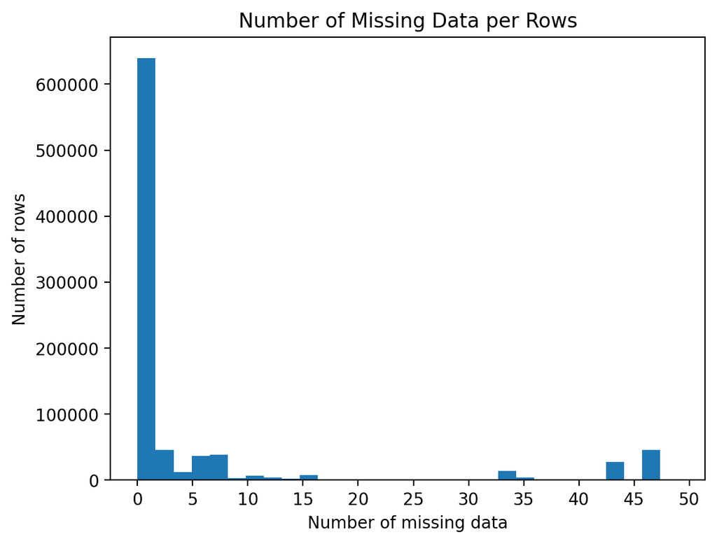

```python
# How much data is missing in each row of the dataset?
num_missing_per_row = azdias_clean.isna().sum(axis=1)
plt.hist(num_missing_per_row, bins=30)
plt.title("Number of Missing Data per Rows")
plt.ylabel("Number of rows")
plt.xlabel("Number of missing data")
plt.xticks(np.arange(0,51,5));
```

```python
# divide the data into two subsets based on the number of missing alues in each row.

row_threshold = 20
azdias_over_threshold = azdias_clean[num_missing_per_row > row_threshold]
azdias_clean = azdias_clean[num_missing_per_row <= row_threshold]
```

```python
max(azdias_clean.isna().sum(axis=1))
```

```
20
```

```python
min(azdias_over_threshold.isna().sum(axis=1))
```

```
21
```

```python
# Compare the distribution of values for at least five columns where there are no or few missing values, between the two subsets.

fig, axes = plt.subplots(nrows=7, ncols=2, figsize=(20, 70))

for row, column in enumerate(azdias_clean.columns[0:7]):
    # Simplifying the data to top 10 categories per column to avoid clutter
    top_categories = azdias_clean[column].value_counts().index[:10]

    sns.countplot(data=azdias_clean[azdias_clean[column].isin(top_categories)],
                  x=column, ax=axes[row, 0])
    axes[row, 0].set_title(f'Below {row_threshold} missing rows')

    sns.countplot(data=azdias_over_threshold[azdias_over_threshold[column].isin(top_categories)],
                  x=column, ax=axes[row, 1])
    axes[row, 1].set_title(f'Over {row_threshold} missing rows')

plt.tight_layout()
plt.show()
```

[figure not shown]

#### Discussion 1.1.3: Assess Missing Data in Each Row

Based on the previous graphs, the data with few missing values is qualitatively different from the data with lots of missing values, the distributions are mostly very different as well.

### Step 1.2: Select and Re-Encode Features

Checking for missing data isn't the only way in which I can prepare a dataset for analysis. Since the unsupervised learning techniques to be used will only work on data that is encoded numerically, I need to make a few encoding changes or additional assumptions to be able to make progress. In addition, while almost all of the values in the dataset are encoded using numbers, not all of them represent numeric values. Check the third column of the feature summary (`feat_info`) for a summary of types of measurement.

- For numeric and interval data, these features can be kept without changes.
- Most of the variables in the dataset are ordinal in nature. While ordinal values may technically be non-linear in spacing, make the simplifying assumption that the ordinal variables can be treated as being interval in nature (that is, kept without any changes).
- Special handling may be necessary for the remaining two variable types: categorical, and 'mixed'.

In the first two parts of this sub-step, I will perform an investigation of the categorical and mixed-type features and make a decision on each of them, whether I will keep, drop, or re-encode each. Then, in the last part, I will create a new data frame with only the selected and engineered columns.

```python
# How many features are there of each data type?
feat_info.groupby("type")["attribute"].count()
```

```
type
categorical    21
interval        1
mixed           7
numeric         7
ordinal        49
Name: attribute, dtype: int64
```

#### Step 1.2.1: Re-Encode Categorical Features

For categorical data, I would ordinarily need to encode the levels as dummy variables. Depending on the number of categories, perform one of the following:

- For binary (two-level) categoricals that take numeric values, I can keep them without needing to do anything.
- There is one binary variable that takes on non-numeric values. For this one, I need to re-encode the values as numbers or create a dummy variable.
- For multi-level categoricals (three or more values), I can choose to encode the values using one-hot encoding

```python
# Assess categorical variables: which are binary, which are multi-level, and which one needs to be re-encoded?
all_categorical = list(feat_info.query('type == "categorical"')["attribute"].values)
all_categorical
```

```
['AGER_TYP',
 'ANREDE_KZ',
 'CJT_GESAMTTYP',
 'FINANZTYP',
 'GFK_URLAUBERTYP',
 'GREEN_AVANTGARDE',
 'LP_FAMILIE_FEIN',
 'LP_FAMILIE_GROB',
 'LP_STATUS_FEIN',
 'LP_STATUS_GROB',
 'NATIONALITAET_KZ',
 'SHOPPER_TYP',
 'SOHO_KZ',
 'TITEL_KZ',
 'VERS_TYP',
 'ZABEOTYP',
 'KK_KUNDENTYP',
 'GEBAEUDETYP',
 'OST_WEST_KZ',
 'CAMEO_DEUG_2015',
 'CAMEO_DEU_2015']
```

```python
categorical_in_azdias = [val for val in all_categorical if val in azdias_clean.columns]
categorical_in_azdias
```

```
['ANREDE_KZ',
 'CJT_GESAMTTYP',
 'FINANZTYP',
 'GFK_URLAUBERTYP',
 'GREEN_AVANTGARDE',
 'LP_FAMILIE_FEIN',
 'LP_FAMILIE_GROB',
 'LP_STATUS_FEIN',
 'LP_STATUS_GROB',
 'NATIONALITAET_KZ',
 'SHOPPER_TYP',
 'SOHO_KZ',
 'VERS_TYP',
 'ZABEOTYP',
 'GEBAEUDETYP',
 'OST_WEST_KZ',
 'CAMEO_DEUG_2015',
 'CAMEO_DEU_2015']
```

```python
binary_categorical = [val for val in categorical_in_azdias if azdias_clean[val].nunique() == 2]
binary_categorical
```

```
['ANREDE_KZ', 'GREEN_AVANTGARDE', 'SOHO_KZ', 'VERS_TYP', 'OST_WEST_KZ']
```

```python
for column in binary_categorical:
    print(f"Unique values for {column} are {azdias_clean[column].unique()}")
```

```
Unique values for ANREDE_KZ are [2 1]
Unique values for GREEN_AVANTGARDE are [0 1]
Unique values for SOHO_KZ are [1. 0.]
Unique values for VERS_TYP are [ 2.  1. nan]
Unique values for OST_WEST_KZ are ['W' 'O']
```

```python
azdias_clean.OST_WEST_KZ = azdias_clean.OST_WEST_KZ.replace("W",0).replace("O",1)
```

```python
azdias_clean.OST_WEST_KZ.value_counts()
```

```
OST_WEST_KZ
0    628987
1    168439
Name: count, dtype: int64
```

```python
# Re-encode categorical variable(s) to be kept in the analysis.
multi_lvl_categorical = [val for val in categorical_in_azdias if azdias_clean[val].nunique() > 2]
multi_lvl_categorical
```

```
['CJT_GESAMTTYP',
 'FINANZTYP',
 'GFK_URLAUBERTYP',
 'LP_FAMILIE_FEIN',
 'LP_FAMILIE_GROB',
 'LP_STATUS_FEIN',
 'LP_STATUS_GROB',
 'NATIONALITAET_KZ',
 'SHOPPER_TYP',
 'ZABEOTYP',
 'GEBAEUDETYP',
 'CAMEO_DEUG_2015',
 'CAMEO_DEU_2015']
```

```python
print(f"There are {len(categorical_in_azdias)} categorical features, {len(binary_categorical)} are binary, and {len(multi_lvl_categorical)} are multi-level categorical.")
```

```
There are 18 categorical features, 5 are binary, and 13 are multi-level categorical.
```

```python
azdias_clean[multi_lvl_categorical].nunique()
```

```
CJT_GESAMTTYP        6
FINANZTYP            6
GFK_URLAUBERTYP     12
LP_FAMILIE_FEIN     11
LP_FAMILIE_GROB      5
LP_STATUS_FEIN      10
LP_STATUS_GROB       5
NATIONALITAET_KZ     3
SHOPPER_TYP          4
ZABEOTYP             6
GEBAEUDETYP          7
CAMEO_DEUG_2015      9
CAMEO_DEU_2015      44
dtype: int64
```

```python
azdias_clean = azdias_clean.drop("CAMEO_DEU_2015", axis=1)
```

```python
multi_lvl_categorical.remove("CAMEO_DEU_2015")
```

```python
for column in multi_lvl_categorical:
    dummy_table = pd.get_dummies(azdias_clean[column], prefix=column)
    azdias_clean = azdias_clean.join(dummy_table)
    azdias_clean = azdias_clean.drop(column, axis=1)
```

```python
azdias_clean.head()
```

|  | ALTERSKATEGORIE_GROB | ANREDE_KZ | FINANZ_MINIMALIST | FINANZ_SPARER | FINANZ_VORSORGER | FINANZ_ANLEGER | FINANZ_UNAUFFAELLIGER | FINANZ_HAUSBAUER | GREEN_AVANTGARDE | HEALTH_TYP | ... | GEBAEUDETYP_8.0 | CAMEO_DEUG_2015_1 | CAMEO_DEUG_2015_2 | CAMEO_DEUG_2015_3 | CAMEO_DEUG_2015_4 | CAMEO_DEUG_2015_5 | CAMEO_DEUG_2015_6 | CAMEO_DEUG_2015_7 | CAMEO_DEUG_2015_8 | CAMEO_DEUG_2015_9 |
| --- | --- | --- | --- | --- | --- | --- | --- | --- | --- | --- | --- | --- | --- | --- | --- | --- | --- | --- | --- | --- | --- |
| 1 | 1.0 | 2 | 1 | 5 | 2 | 5 | 4 | 5 | 0 | 3.0 | ... | True | False | False | False | False | False | False | False | True | False |
| 2 | 3.0 | 2 | 1 | 4 | 1 | 2 | 3 | 5 | 1 | 3.0 | ... | False | False | False | False | True | False | False | False | False | False |
| 3 | 4.0 | 2 | 4 | 2 | 5 | 2 | 1 | 2 | 0 | 2.0 | ... | False | False | True | False | False | False | False | False | False | False |
| 4 | 3.0 | 1 | 4 | 3 | 4 | 1 | 3 | 2 | 0 | 3.0 | ... | False | False | False | False | False | False | True | False | False | False |
| 5 | 1.0 | 2 | 3 | 1 | 5 | 2 | 2 | 5 | 0 | 3.0 | ... | False | False | False | False | False | False | False | False | True | False |

5 rows × 150 columns

#### Discussion 1.2.1: Re-Encode Categorical Features

First, I made a list with all categorical features and split it into binary categorical features and multi-class categorical features, then I re-encoded the values in the `OST_WEST_KZ` column by making them numerical. next, I dropped the column with 44 classes `CAMEO_DEU_2015` as this would just add more noise to the data, finally I one-hot encoded all the remaining multiclass categorical columns using pandas get_dummies function.

#### Step 1.2.2: Engineer Mixed-Type Features

There are a handful of features that are marked as "mixed" in the feature summary that require special treatment in order to be included in the analysis. There are two in particular that deserve attention:

- "PRAEGENDE_JUGENDJAHRE" combines information on three dimensions: generation by decade, movement (mainstream vs. avantgarde), and nation (east vs. west). While there aren't enough levels to disentangle east from west, I should create two new variables to capture the other two dimensions: an interval-type variable for decade, and a binary variable for movement.
- "CAMEO_INTL_2015" combines information on two axes: wealth and life stage. Break up the two-digit codes by their 'tens'-place and 'ones'-place digits into two new ordinal variables (which, for the purposes of this project, is equivalent to just treating them as their raw numeric values).

```python
feat_info.query('type == "mixed"')
```

|  | attribute | information_level | type | missing_or_unknown | missing_or_unknown2 |
| --- | --- | --- | --- | --- | --- |
| 15 | LP_LEBENSPHASE_FEIN | person | mixed | [0] | 0 |
| 16 | LP_LEBENSPHASE_GROB | person | mixed | [0] | 0 |
| 22 | PRAEGENDE_JUGENDJAHRE | person | mixed | [-1,0] | -1,0 |
| 56 | WOHNLAGE | building | mixed | [-1] | -1 |
| 59 | CAMEO_INTL_2015 | microcell_rr4 | mixed | [-1,XX] | -1,XX |
| 64 | KBA05_BAUMAX | microcell_rr3 | mixed | [-1,0] | -1,0 |
| 79 | PLZ8_BAUMAX | macrocell_plz8 | mixed | [-1,0] | -1,0 |

### from the `Data_Dictionary.md` file

### 1.18. PRAEGENDE_JUGENDJAHRE

Dominating movement of person's Ith (avantgarde vs. mainstream; east vs. west)

- -1: unknown
- 0: unknown
- 1: 40s - war years (Mainstream, E+W)
- 2: 40s - reconstruction years (Avantgarde, E+W)
- 3: 50s - economic miracle (Mainstream, E+W)
- 4: 50s - milk bar / Individualisation (Avantgarde, E+W)
- 5: 60s - economic miracle (Mainstream, E+W)
- 6: 60s - generation 68 / student protestors (Avantgarde, W)
- 7: 60s - opponents to the building of the Wall (Avantgarde, E)
- 8: 70s - family orientation (Mainstream, E+W)
- 9: 70s - peace movement (Avantgarde, E+W)
- 10: 80s - Generation Golf (Mainstream, W)
- 11: 80s - ecological awareness (Avantgarde, W)
- 12: 80s - FDJ / communist party Ith organisation (Mainstream, E)
- 13: 80s - Swords into ploughshares (Avantgarde, E)
- 14: 90s - digital media kids (Mainstream, E+W)
- 15: 90s - ecological awareness (Avantgarde, E+W)

```python
# Investigate "PRAEGENDE_JUGENDJAHRE" and engineer two new variables.
azdias_clean.PRAEGENDE_JUGENDJAHRE.value_counts()
```

```
PRAEGENDE_JUGENDJAHRE
14.0    182903
8.0     141542
10.0     85767
5.0      84665
3.0      53822
15.0     42521
11.0     35735
9.0      33563
6.0      25651
12.0     24440
1.0      20662
4.0      20450
2.0       7479
13.0      5759
7.0       4009
Name: count, dtype: int64
```

```python
azdias_clean.PRAEGENDE_JUGENDJAHRE.dtype
```

```
dtype('float64')
```

```python
decade = {-1:np.nan, 0: np.nan, 1:40, 2:40, 3:50, 4:50, 5:60, 6:60, 7:60, 8:70, 9:70, 10:80, 11:80, 12:80, 13:80, 14:90, 15:90}
```

```python
azdias_clean["PRAEGENDE_JUGENDJAHRE_decade"] = azdias_clean.PRAEGENDE_JUGENDJAHRE.map(decade)
```

```python
azdias_clean.PRAEGENDE_JUGENDJAHRE_decade.value_counts()
```

```
PRAEGENDE_JUGENDJAHRE_decade
90.0    225424
70.0    175105
80.0    151701
60.0    114325
50.0     74272
40.0     28141
Name: count, dtype: int64
```

```python
movement = {-1:np.nan, 0:np.nan, 1:0, 2:1, 3:0, 4:1, 5:0, 6:1, 7:1, 8:0, 9:1, 10:0, 11:1, 12:0, 13:1, 14:0, 15:1}
```

```python
azdias_clean["PRAEGENDE_JUGENDJAHRE_movement"] = azdias_clean.PRAEGENDE_JUGENDJAHRE.map(movement)
```

```python
azdias_clean.PRAEGENDE_JUGENDJAHRE_movement.value_counts()
```

```
PRAEGENDE_JUGENDJAHRE_movement
0.0    593801
1.0    175167
Name: count, dtype: int64
```

### from the `Data_Dictionary.md` file

### 4.3. CAMEO_INTL_2015

German CAMEO: Wealth / Life Stage Typology, mapped to international code

- -1: unknown
- 11: Wealthy Households - Pre-Family Couples & Singles
- 12: Wealthy Households - Young Couples With Children
- 13: Wealthy Households - Families With School Age Children
- 14: Wealthy Households - Older Families & Mature Couples
- 15: Wealthy Households - Elders In Retirement
- 21: Prosperous Households - Pre-Family Couples & Singles
- 22: Prosperous Households - Young Couples With Children
- 23: Prosperous Households - Families With School Age Children
- 24: Prosperous Households - Older Families & Mature Couples
- 25: Prosperous Households - Elders In Retirement
- 31: Comfortable Households - Pre-Family Couples & Singles
- 32: Comfortable Households - Young Couples With Children
- 33: Comfortable Households - Families With School Age Children
- 34: Comfortable Households - Older Families & Mature Couples
- 35: Comfortable Households - Elders In Retirement
- 41: Less Affluent Households - Pre-Family Couples & Singles
- 42: Less Affluent Households - Young Couples With Children
- 43: Less Affluent Households - Families With School Age Children
- 44: Less Affluent Households - Older Families & Mature Couples
- 45: Less Affluent Households - Elders In Retirement
- 51: Poorer Households - Pre-Family Couples & Singles
- 52: Poorer Households - Young Couples With Children
- 53: Poorer Households - Families With School Age Children
- 54: Poorer Households - Older Families & Mature Couples
- 55: Poorer Households - Elders In Retirement
- XX: unknown

```python
azdias_clean.CAMEO_INTL_2015.value_counts()
```

```
CAMEO_INTL_2015
51    133673
41     92309
24     91099
14     62851
43     56653
54     45376
25     39605
22     33137
23     26667
13     26311
45     26126
55     23939
52     20538
31     18979
34     18517
15     16966
44     14817
12     13234
35     10352
32     10346
33      9928
Name: count, dtype: int64
```

```python
azdias_clean.CAMEO_INTL_2015.dtype
```

```
dtype('O')
```

```python
# Investigate "CAMEO_INTL_2015" and engineer two new variables.
wealth = {-1:np.nan, '11':1, '12':1, '13':1, '14':1, '15':1, '21':2, '22':2, '23':2, '24':2, '25':2,'31':3,
          '32':3, '33':3, '34':3, '35':3, '41':4, '42':4, '43':4, '44':4, '45':4,'51':5, '52':5, '53':5, '54':5, '55':5}
```

```python
azdias_clean["CAMEO_INTL_2015_wealth"] = azdias_clean.CAMEO_INTL_2015.map(wealth)
```

```python
azdias_clean.CAMEO_INTL_2015_wealth.value_counts()
```

```
CAMEO_INTL_2015_wealth
5.0    223526
2.0    190508
4.0    189905
1.0    119362
3.0     68122
Name: count, dtype: int64
```

```python
life_stage = {'11':1, '12':2, '13':3, '14':4, '15':5, '21':1, '22':2, '23':3, '24':4, '25':5,'31':1,
              '32':2, '33':3, '34':4, '35':5, '41':1, '42':2, '43':3, '44':4, '45':5,'51':1, '52':2, '53':3, '54':4, '55':5}
```

```python
azdias_clean["CAMEO_INTL_2015_life_stage"] = azdias_clean.CAMEO_INTL_2015.map(life_stage)
```

```python
azdias_clean.CAMEO_INTL_2015_life_stage.value_counts()
```

```
CAMEO_INTL_2015_life_stage
1.0    244961
4.0    232660
3.0    119559
5.0    116988
2.0     77255
Name: count, dtype: int64
```

```python
azdias_clean = azdias_clean.drop(["CAMEO_INTL_2015","PRAEGENDE_JUGENDJAHRE"],axis=1)
```

#### Discussion 1.2.2: Engineer Mixed-Type Features

I re-encoded the data in the `PRAEGENDE_JUGENDJAHRE` column and `CAMEO_INTL_2015` from the Data_Dictionary.md file and split each of them into two more columns and then dropped the original columns. I also decided to keep the other columns as they are.

#### Step 1.2.3: Complete Feature Selection

In order to finish this step up, I need to make sure that the data frame now only has the columns that I want to keep. To summarize, the dataframe should consist of the following:

- All numeric, interval, and ordinal type columns from the original dataset.
- Binary categorical features (all numerically-encoded).
- Engineered features from other multi-level categorical features and mixed features.

### Step 1.3: Create a Cleaning Function

Even though I've finished cleaning up the general population demographics data, it's important to look ahead to the future and realize that I'll need to perform the same cleaning steps on the customer demographics data. In this substep, I'll write the function below to execute the main feature selection, encoding, and re-engineering steps I performed above. Then, when it comes to looking at the customer data in Step 3, i can just run this function on that DataFrame to get the trimmed dataset in a single step.

```python
def clean_data(df):
    """
    Perform feature trimming, re-encoding, and engineering for demographics
    data

    INPUT: Demographics DataFrame
    OUTPUT: Trimmed and cleaned demographics DataFrame
    """

    # convert missing value codes into NaNs, ...
    feat_info["missing_or_unknown2"] = feat_info.missing_or_unknown.str.replace("[","").str.replace("]","")

    for column in range(df.shape[1]):
        missing_list = feat_info.iloc[column,4].split(",")
        missing_list = [int(val) if (val != '' and val != 'X' and val != 'XX') else val for val in missing_list]
        if missing_list != ['']:
            df = df.replace({feat_info.iloc[column]['attribute']: missing_list}, np.nan)

    # remove selected columns and rows, ...
    df = azdias.drop(['AGER_TYP', 'GEBURTSJAHR', 'TITEL_KZ', 'ALTER_HH', 'KK_KUNDENTYP', 'KBA05_BAUMAX'], axis=1)
    num_missing_per_row = df.isna().sum(axis=1)
    df = df[num_missing_per_row <= 20]


    # select, re-encode, and engineer column values.
    if "OST_WEST_KZ" in df.columns:
        df["OST_WEST_KZ"] = df["OST_WEST_KZ"].replace("W",0).replace("O",1)

    all_categorical = list(feat_info.query('type == "categorical"')["attribute"].values)
    categorical_in_azdias = [val for val in all_categorical if val in df.columns]
    multi_lvl_categorical = [val for val in categorical_in_azdias if df[val].nunique() > 2]
    multi_lvl_categorical.remove("CAMEO_DEU_2015")
    df = df.drop("CAMEO_DEU_2015", axis=1)

    for column in multi_lvl_categorical:
        dummy_table = pd.get_dummies(df[column], prefix=column)
        df = df.join(dummy_table)
        df = df.drop(column, axis=1)

    decade = {-1:np.nan, 0: np.nan, 1:40, 2:40, 3:50, 4:50, 5:60, 6:60, 7:60, 8:70, 9:70, 10:80, 11:80, 12:80, 13:80, 14:90, 15:90}
    movement = {-1:np.nan, 0:np.nan, 1:0, 2:1, 3:0, 4:1, 5:0, 6:1, 7:1, 8:0, 9:1, 10:0, 11:1, 12:0, 13:1, 14:0, 15:1}

    df["PRAEGENDE_JUGENDJAHRE_decade"] = df.PRAEGENDE_JUGENDJAHRE.map(decade)
    df["PRAEGENDE_JUGENDJAHRE_movement"] = df.PRAEGENDE_JUGENDJAHRE.map(movement)

    wealth = {-1:np.nan, '11':1, '12':1, '13':1, '14':1, '15':1, '21':2, '22':2, '23':2, '24':2, '25':2,'31':3,
          '32':3, '33':3, '34':3, '35':3, '41':4, '42':4, '43':4, '44':4, '45':4,'51':5, '52':5, '53':5, '54':5, '55':5}
    life_stage = {'11':1, '12':2, '13':3, '14':4, '15':5, '21':1, '22':2, '23':3, '24':4, '25':5,'31':1,
              '32':2, '33':3, '34':4, '35':5, '41':1, '42':2, '43':3, '44':4, '45':5,'51':1, '52':2, '53':3, '54':4, '55':5}

    df["CAMEO_INTL_2015_wealth"] = df.CAMEO_INTL_2015.map(wealth)
    df["CAMEO_INTL_2015_life_stage"] = df.CAMEO_INTL_2015.map(life_stage)
    df = df.drop(["CAMEO_INTL_2015","PRAEGENDE_JUGENDJAHRE"],axis=1)

    # Return the cleaned dataframe.
    return df
```

## Step 2: Feature Transformation

### Step 2.1: Apply Feature Scaling

Before we apply dimensionality reduction techniques to the data, we need to perform feature scaling so that the principal component vectors are not influenced by the natural differences in scale for features.

```python
from sklearn.impute import SimpleImputer
from sklearn.preprocessing import StandardScaler

# Assuming azdias_clean is your DataFrame
# Create a SimpleImputer object with strategy 'mean'
imputer = SimpleImputer(strategy="mean")

# Fit and transform the data using the imputer
means = imputer.fit_transform(azdias_clean)

# Create a new DataFrame from the imputed data
azdias_clean = pd.DataFrame(means, columns=azdias_clean.columns)

# Optionally, apply StandardScaler if needed
scaler = StandardScaler()
azdias_clean_scaled = scaler.fit_transform(azdias_clean)

# Convert the scaled data back into a DataFrame if needed for further processing
azdias_clean_scaled = pd.DataFrame(azdias_clean_scaled, columns=azdias_clean.columns)

# Display the first few rows of the imputed (and possibly scaled) DataFrame
azdias_clean.head()
```

|  | ALTERSKATEGORIE_GROB | ANREDE_KZ | FINANZ_MINIMALIST | FINANZ_SPARER | FINANZ_VORSORGER | FINANZ_ANLEGER | FINANZ_UNAUFFAELLIGER | FINANZ_HAUSBAUER | GREEN_AVANTGARDE | HEALTH_TYP | ... | CAMEO_DEUG_2015_4 | CAMEO_DEUG_2015_5 | CAMEO_DEUG_2015_6 | CAMEO_DEUG_2015_7 | CAMEO_DEUG_2015_8 | CAMEO_DEUG_2015_9 | PRAEGENDE_JUGENDJAHRE_decade | PRAEGENDE_JUGENDJAHRE_movement | CAMEO_INTL_2015_wealth | CAMEO_INTL_2015_life_stage |
| --- | --- | --- | --- | --- | --- | --- | --- | --- | --- | --- | --- | --- | --- | --- | --- | --- | --- | --- | --- | --- | --- |
| 0 | 1.0 | 2.0 | 1.0 | 5.0 | 2.0 | 5.0 | 4.0 | 5.0 | 0.0 | 3.0 | ... | 0.0 | 0.0 | 0.0 | 0.0 | 1.0 | 0.0 | 90.0 | 0.0 | 5.0 | 1.0 |
| 1 | 3.0 | 2.0 | 1.0 | 4.0 | 1.0 | 2.0 | 3.0 | 5.0 | 1.0 | 3.0 | ... | 1.0 | 0.0 | 0.0 | 0.0 | 0.0 | 0.0 | 90.0 | 1.0 | 2.0 | 4.0 |
| 2 | 4.0 | 2.0 | 4.0 | 2.0 | 5.0 | 2.0 | 1.0 | 2.0 | 0.0 | 2.0 | ... | 0.0 | 0.0 | 0.0 | 0.0 | 0.0 | 0.0 | 70.0 | 0.0 | 1.0 | 2.0 |
| 3 | 3.0 | 1.0 | 4.0 | 3.0 | 4.0 | 1.0 | 3.0 | 2.0 | 0.0 | 3.0 | ... | 0.0 | 0.0 | 1.0 | 0.0 | 0.0 | 0.0 | 70.0 | 0.0 | 4.0 | 3.0 |
| 4 | 1.0 | 2.0 | 3.0 | 1.0 | 5.0 | 2.0 | 2.0 | 5.0 | 0.0 | 3.0 | ... | 0.0 | 0.0 | 0.0 | 0.0 | 1.0 | 0.0 | 50.0 | 0.0 | 5.0 | 4.0 |

5 rows × 152 columns

```python
azdias_clean.isna().sum().sum()
```

```
0
```

```python
# Apply feature scaling to the general population demographics data.

scaler = StandardScaler()
scaled_features = scaler.fit_transform(azdias_clean)
azdias_clean = pd.DataFrame(scaled_features, columns=azdias_clean.columns)
azdias_clean.head()
```

|  | ALTERSKATEGORIE_GROB | ANREDE_KZ | FINANZ_MINIMALIST | FINANZ_SPARER | FINANZ_VORSORGER | FINANZ_ANLEGER | FINANZ_UNAUFFAELLIGER | FINANZ_HAUSBAUER | GREEN_AVANTGARDE | HEALTH_TYP | ... | CAMEO_DEUG_2015_4 | CAMEO_DEUG_2015_5 | CAMEO_DEUG_2015_6 | CAMEO_DEUG_2015_7 | CAMEO_DEUG_2015_8 | CAMEO_DEUG_2015_9 | PRAEGENDE_JUGENDJAHRE_decade | PRAEGENDE_JUGENDJAHRE_movement | CAMEO_INTL_2015_wealth | CAMEO_INTL_2015_life_stage |
| --- | --- | --- | --- | --- | --- | --- | --- | --- | --- | --- | --- | --- | --- | --- | --- | --- | --- | --- | --- | --- | --- |
| 0 | -1.765755 | 0.958071 | -1.494609 | 1.538200 | -1.040726 | 1.466448 | 0.959677 | 1.338816 | -0.530567 | 1.085565 | ... | -0.386934 | -0.27284 | -0.391203 | -0.329047 | 2.221008 | -0.396115 | 1.165509 | -0.553091 | 1.190912 | -1.266147 |
| 1 | 0.201306 | 0.958071 | -1.494609 | 0.864824 | -1.766955 | -0.570799 | 0.244962 | 1.338816 | 1.884775 | 1.085565 | ... | 2.584420 | -0.27284 | -0.391203 | -0.329047 | -0.450246 | -0.396115 | 1.165509 | 1.874931 | -0.865304 | 0.761893 |
| 2 | 1.184837 | 0.958071 | 0.683150 | -0.481928 | 1.137960 | -0.570799 | -1.184467 | -0.792034 | -0.530567 | -0.270002 | ... | -0.386934 | -0.27284 | -0.391203 | -0.329047 | -0.450246 | -0.396115 | -0.231940 | -0.553091 | -1.550709 | -0.590134 |
| 3 | 0.201306 | -1.043765 | 0.683150 | 0.191448 | 0.411731 | -1.249881 | 0.244962 | -0.792034 | -0.530567 | 1.085565 | ... | -0.386934 | -0.27284 | 2.556220 | -0.329047 | -0.450246 | -0.396115 | -0.231940 | -0.553091 | 0.505507 | 0.085880 |
| 4 | -1.765755 | 0.958071 | -0.042770 | -1.155304 | 1.137960 | -0.570799 | -0.469752 | 1.338816 | -0.530567 | 1.085565 | ... | -0.386934 | -0.27284 | -0.391203 | -0.329047 | 2.221008 | -0.396115 | -1.629389 | -0.553091 | 1.190912 | 0.761893 |

5 rows × 152 columns

### Discussion 2.1: Apply Feature Scaling

I decided to fill all missing values in each column with the mean of this column and then used standardization to scale all the columns.

### Step 2.2: Perform Dimensionality Reduction

On my scaled data, I'm now ready to apply dimensionality reduction techniques.

```python
# Apply PCA to the data.

from sklearn.decomposition import PCA

n_components = azdias_clean.shape[1] // 2
pca = PCA(n_components=n_components)
pca.fit(azdias_clean)
```

```
PCA(n_components=76)
```

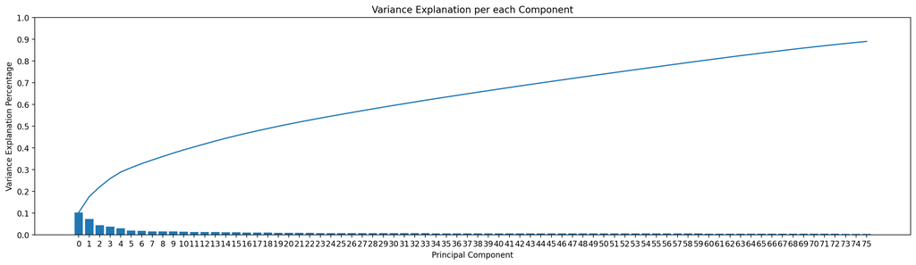

```python
# Investigate the variance accounted for by each principal component.

plt.figure(figsize=(20,5))
plt.bar(np.arange(n_components), pca.explained_variance_ratio_)
cumul_vals = np.cumsum(pca.explained_variance_ratio_)
plt.plot(np.arange(n_components),np.cumsum(pca.explained_variance_ratio_))
plt.title("Variance Explanation per each Component")
plt.xlabel("Principal Component")
plt.xticks(np.arange(n_components))
plt.ylabel("Variance Explanation Percentage")
plt.yticks(np.arange(0,1.01,0.1));
```

```python
pca.explained_variance_ratio_.sum()
```

```
0.8903958103731705
```

```python
# Re-apply PCA to the data while selecting for number of components to retain.
azdias_clean_dr = pca.transform(azdias_clean)
```

```python
azdias_clean_dr.shape
```

```
(797426, 76)
```

### Discussion 2.2: Perform Dimensionality Reduction

I decided to make the principal components half the original columns which is 76 components. the cumulative variance explained 89% of the data.

### Step 2.3: Interpret Principal Components

Now that we have our transformed principal components, it's a nice idea to check out the weight of each variable on the first few components to see if they can be interpreted in some fashion.

Each principal component is a unit vector that points in the direction of highest variance (after accounting for the variance captured by earlier principal components). The further a weight is from zero, the more the principal component is in the direction of the corresponding feature. If two features have large weights of the same sign (both positive or both negative), then increases in one tend expect to be associated with increases in the other. To contrast, features with different signs can be expected to show a negative correlation: increases in one variable should result in a decrease in the other.

- To investigate the features, I should map each weight to their corresponding feature name, then sort the features according to weight. The most interesting features for each principal component, then, will be those at the beginning and end of the sorted list. Use the data dictionary document to help me understand these most prominent features, their relationships, and what a positive or negative value on the principal component might indicate.
- I should investigate and interpret feature associations from the first three principal components in this substep. To help facilitate this, I should write a function that I can call at any time to print the sorted list of feature weights, for the *i*-th principal component. This might come in handy in the next step of the project, when I interpret the tendencies of the discovered clusters.

```python
azdias_clean.shape
```

```
(797426, 152)
```

```python
def pca_map(pca, pc_order):
    return pd.DataFrame(pca.components_, columns=azdias_clean.columns).iloc[pc_order].sort_values(ascending=False)
```

```python
# Map weights for the first principal component to corresponding feature names
# and then print the linked values, sorted by weight.theses
pca_map(pca,0)
```

```
LP_STATUS_GROB_1.0        0.192664
HH_EINKOMMEN_SCORE        0.182046
PLZ8_ANTG3                0.181113
CAMEO_INTL_2015_wealth    0.176931
PLZ8_ANTG4                0.176105
                            ...
KBA05_GBZ                -0.179468
PLZ8_ANTG1               -0.181434
FINANZ_MINIMALIST        -0.186051
KBA05_ANTG1              -0.188700
MOBI_REGIO               -0.201909
Name: 0, Length: 152, dtype: float64
```

```python
# Map weights for the second principal component to corresponding feature names
# and then print the linked values, sorted by weight.
pca_map(pca,1)
```

```
ALTERSKATEGORIE_GROB            0.236160
FINANZ_VORSORGER                0.222054
ZABEOTYP_3                      0.200016
SEMIO_ERL                       0.181067
SEMIO_LUST                      0.164838
                                  ...
SEMIO_TRADV                    -0.209788
FINANZ_UNAUFFAELLIGER          -0.216316
SEMIO_REL                      -0.216806
FINANZ_SPARER                  -0.231499
PRAEGENDE_JUGENDJAHRE_decade   -0.240387
Name: 1, Length: 152, dtype: float64
```

```python
# Map weights for the third principal component to corresponding feature names
# and then print the linked values, sorted by weight.
pca_map(pca,2)
```

```
SEMIO_VERT     0.317388
SEMIO_FAM      0.258366
SEMIO_SOZ      0.255955
SEMIO_KULT     0.249706
FINANZTYP_5    0.136366
                 ...
SEMIO_ERL     -0.206725
SEMIO_KRIT    -0.266632
SEMIO_DOM     -0.279404
SEMIO_KAEM    -0.311488
ANREDE_KZ     -0.342625
Name: 2, Length: 152, dtype: float64
```

### Discussion 2.3: Interpret Principal Components

#### First Principle Component:

Using the `Data_Dictionary.md` file:

##### Positive Weights:

1- `LP_STATUS_GROB_1.0` (Social status: low-income)  
2- `HH_EINKOMMEN_SCORE` (household net income)  
3- `PLZ8_ANTG3` (number of 6-10 family houses in the PLZ8 region)

## Step 3: Clustering

### Step 3.1: Apply Clustering to General Population

I've assessed and cleaned the demographics data, then scaled and transformed them. Now, it's time to see how the data clusters in the principal components space. In this substep, I will apply k-means clustering to the dataset and use the average within-cluster distances from each point to their assigned cluster's centroid to decide on a number of clusters to keep.

```python
# Over a number of different cluster counts...
from sklearn.cluster import KMeans
kmeans_scores = []
n_clusters_list = list(range(3, 30))

    # run k-means clustering on the data and...
for n_clusters in n_clusters_list:
    kmeans = KMeans(n_clusters=n_clusters, n_init='auto')
    kmeans.fit(azdias_clean_dr)
    # compute the average within-cluster distances.
    kmeans_score = np.abs(kmeans.score(azdias_clean_dr))
    kmeans_scores.append(kmeans_score)
```

[output not shown]

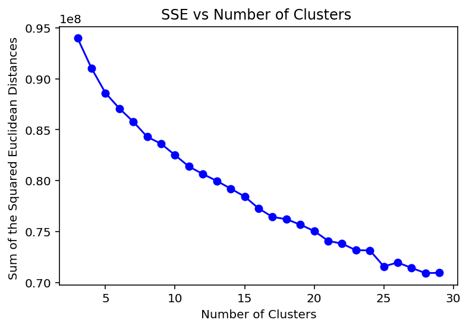

```python
# Investigate the change in within-cluster distance across number of clusters.
# HINT: Use matplotlib's plot function to visualize this relationship.

plt.plot(n_clusters_list, kmeans_scores, color="b", marker="o")
plt.title("SSE vs Number of Clusters ")
plt.xlabel("Number of Clusters")
plt.ylabel("Sum of the Squared Euclidean Distances ")
```

```python
# Re-fit the k-means model with the selected number of clusters and obtain
# cluster predictions for the general population demographics data.
kmeans = KMeans(n_clusters=25)
kmeans = kmeans.fit(azdias_clean_dr)
azdias_predictions = kmeans.predict(azdias_clean_dr)
```

### Discussion 3.1: Apply Clustering to General Population

After running the kmeans clustering algorithm from number of clusters ranging between 3 and 30, I found the best probable number of clusters is 25 by inspecting the line chart representing the SSE to each choice of clusters and using the elbow method.

### Step 3.2: Apply All Steps to the Customer Data

```python
# Load in the customer demographics data.
customers = pd.read_csv("Udacity_CUSTOMERS_Subset.csv", sep=";")
```

```python
customers.shape
```

```
(191652, 85)
```

```python
# Apply preprocessing, feature transformation, and clustering from the general
# demographics onto the customer data, obtaining cluster predictions for the
# customer demographics data.
customers_clean = clean_data(customers)
```

```python
customers_clean.shape
```

```
(797426, 152)
```

```python
means = imputer.transform(customers_clean)
customers_clean = pd.DataFrame(means, columns=customers_clean.columns)
```

```python
customers_clean.isna().sum().sum()
```

```
0
```

```python
# scale dataset
customers_standardized =  scaler.fit_transform(customers_clean)
customers_standardized = pd.DataFrame(customers_standardized, columns=customers_clean.columns)
# perform DR
customers_dr = pca.fit_transform(customers_clean)

# predict using kmeans model
customers_predictions = kmeans.predict(customers_dr)
```

```python
azdias_clean.shape
```

```
(797426, 152)
```

```python
customers_clean.shape
```

```
(797426, 152)
```

### Step 3.3: Compare Customer Data to Demographics Data

At this point, I have clustered data based on demographics of the general population of Germany, and seen how the customer data for a mail-order sales company maps onto those demographic clusters. In this final substep, I will compare the two cluster distributions to see where the strongest customer base for the company is.

Considering the proportion of persons in each cluster for the general population, and the proportions for the customers. If we think the company's customer base to be universal, then the cluster assignment proportions should be fairly similar between the two. If there are only particular segments of the population that are interested in the company's products, then we should see a mismatch from one to the other. If there is a higher proportion of persons in a cluster for the customer data compared to the general population (e.g. 5% of persons are assigned to a cluster for the general population, but 15% of the customer data is closest to that cluster's centroid) then that suggests the people in that cluster to be a target audience for the company. On the other hand, the proportion of the data in a cluster being larger in the general population than the customer data (e.g. only 2% of customers closest to a population centroid that captures 6% of the data) suggests that group of persons to be outside of the target demographics.

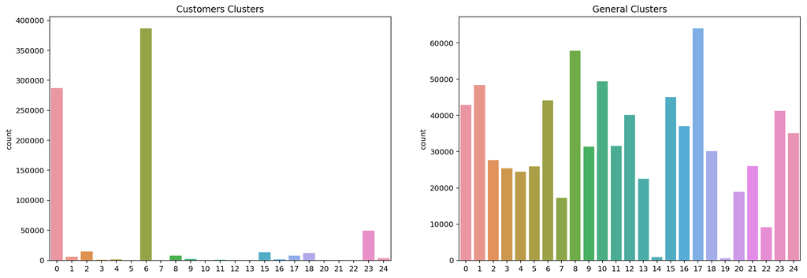

```python
# Compare the proportion of data in each cluster for the customer data to the
# proportion of data in each cluster for the general population.
fig, (ax1,ax2) = plt.subplots(nrows=1, ncols=2, figsize=(18,6))
sns.countplot(customers_predictions, ax=ax1)
ax1.set_title(f'Customers Clusters')
sns.countplot(azdias_predictions, ax=ax2)
ax2.set_title(f'General Clusters');
```

```python
# What kinds of people are part of a cluster that is overrepresented in the
# customer data compared to the general population?
centroid_6 = scaler.inverse_transform(pca.inverse_transform(kmeans.cluster_centers_[6]))
```

```python
over_represented = pd.Series(centroid_6, index=customers_clean.columns)
over_represented
```

```
ALTERSKATEGORIE_GROB                 5.983588
ANREDE_KZ                            2.309750
FINANZ_MINIMALIST                    7.116731
FINANZ_SPARER                        7.116046
FINANZ_VORSORGER                     7.921963
FINANZ_ANLEGER                       7.628463
FINANZ_UNAUFFAELLIGER                6.602350
FINANZ_HAUSBAUER                     7.595324
GREEN_AVANTGARDE                     0.341795
HEALTH_TYP                           3.809783
LP_LEBENSPHASE_FEIN                244.573653
LP_LEBENSPHASE_GROB                 26.556320
RETOURTYP_BK_S                       8.220229
SEMIO_SOZ                           12.534255
SEMIO_FAM                           10.853031
SEMIO_REL                           10.974388
SEMIO_MAT                           10.639734
SEMIO_VERT                          12.151729
SEMIO_LUST                          15.341697
SEMIO_ERL                           13.656062
SEMIO_KULT                          11.679652
SEMIO_RAT                           10.046410
SEMIO_KRIT                          13.202863
SEMIO_DOM                           13.083537
SEMIO_KAEM                          12.625766
SEMIO_PFLICHT                       11.551530
SEMIO_TRADV                          9.534728
SOHO_KZ                              0.009265
VERS_TYP                             2.291987
ANZ_PERSONEN                         4.094592
                                     ...
SHOPPER_TYP_0.0                      0.251694
SHOPPER_TYP_1.0                      0.432691
SHOPPER_TYP_2.0                      0.378019
SHOPPER_TYP_3.0                      0.285461
ZABEOTYP_1                           0.220203
ZABEOTYP_2                           0.049285
ZABEOTYP_3                           0.504424
ZABEOTYP_4                           0.383073
ZABEOTYP_5                           0.133116
ZABEOTYP_6                           0.111089
GEBAEUDETYP_1.0                      0.793730
GEBAEUDETYP_2.0                      0.006591
GEBAEUDETYP_3.0                      0.382852
GEBAEUDETYP_4.0                      0.001155
GEBAEUDETYP_5.0                      0.000001
GEBAEUDETYP_6.0                      0.000790
GEBAEUDETYP_8.0                      0.258486
CAMEO_DEUG_2015_1                    0.056019
CAMEO_DEUG_2015_2                    0.132183
CAMEO_DEUG_2015_3                    0.148334
CAMEO_DEUG_2015_4                    0.172855
CAMEO_DEUG_2015_5                    0.085769
CAMEO_DEUG_2015_6                    0.188611
CAMEO_DEUG_2015_7                    0.126063
CAMEO_DEUG_2015_8                    0.198830
CAMEO_DEUG_2015_9                    0.204609
PRAEGENDE_JUGENDJAHRE_decade      1467.855705
PRAEGENDE_JUGENDJAHRE_movement       0.341795
CAMEO_INTL_2015_wealth               8.133152
CAMEO_INTL_2015_life_stage           7.419649
Length: 152, dtype: float64
```

```python
# What kinds of people are part of a cluster that is underrepresented in the
# customer data compared to the general population?
centroid_17 = scaler.inverse_transform(pca.inverse_transform(kmeans.cluster_centers_[17]))
```

```python
under_represented = pd.Series(centroid_17, index=customers_clean.columns)
under_represented
```

```
ALTERSKATEGORIE_GROB                 5.360906
ANREDE_KZ                            2.266872
FINANZ_MINIMALIST                    7.326874
FINANZ_SPARER                        6.585070
FINANZ_VORSORGER                     8.461501
FINANZ_ANLEGER                       6.680694
FINANZ_UNAUFFAELLIGER                5.974215
FINANZ_HAUSBAUER                     7.981501
GREEN_AVANTGARDE                     0.296921
HEALTH_TYP                           4.016017
LP_LEBENSPHASE_FEIN                175.222337
LP_LEBENSPHASE_GROB                 19.588573
RETOURTYP_BK_S                       8.502495
SEMIO_SOZ                           12.436723
SEMIO_FAM                           12.635513
SEMIO_REL                           12.434818
SEMIO_MAT                           12.297583
SEMIO_VERT                          12.530781
SEMIO_LUST                          12.339224
SEMIO_ERL                           12.393393
SEMIO_KULT                          13.014573
SEMIO_RAT                           10.982034
SEMIO_KRIT                          11.940466
SEMIO_DOM                           12.428784
SEMIO_KAEM                          12.440709
SEMIO_PFLICHT                       12.995632
SEMIO_TRADV                         10.731493
SOHO_KZ                              0.009167
VERS_TYP                             2.259351
ANZ_PERSONEN                         3.397204
                                     ...
SHOPPER_TYP_0.0                      0.290986
SHOPPER_TYP_1.0                      0.409473
SHOPPER_TYP_2.0                      0.369744
SHOPPER_TYP_3.0                      0.275406
ZABEOTYP_1                           0.218106
ZABEOTYP_2                           0.046773
ZABEOTYP_3                           0.489370
ZABEOTYP_4                           0.368591
ZABEOTYP_5                           0.133175
ZABEOTYP_6                           0.134624
GEBAEUDETYP_1.0                      0.793295
GEBAEUDETYP_2.0                      0.006599
GEBAEUDETYP_3.0                      0.307064
GEBAEUDETYP_4.0                      0.001162
GEBAEUDETYP_5.0                      0.000001
GEBAEUDETYP_6.0                      0.000794
GEBAEUDETYP_8.0                      0.330135
CAMEO_DEUG_2015_1                    0.056275
CAMEO_DEUG_2015_2                    0.137202
CAMEO_DEUG_2015_3                    0.163540
CAMEO_DEUG_2015_4                    0.160631
CAMEO_DEUG_2015_5                    0.082243
CAMEO_DEUG_2015_6                    0.154603
CAMEO_DEUG_2015_7                    0.117632
CAMEO_DEUG_2015_8                    0.281930
CAMEO_DEUG_2015_9                    0.165651
PRAEGENDE_JUGENDJAHRE_decade      1435.153248
PRAEGENDE_JUGENDJAHRE_movement       0.296921
CAMEO_INTL_2015_wealth               8.125612
CAMEO_INTL_2015_life_stage           7.795939
Length: 152, dtype: float64
```

### Discussion 3.3: Compare Customer Data to Demographics Data

- Females (`ANREDE_KZ` = 2.309750)
- Older than 60 (`ALTERSKATEGORIE_GROB` = 5.983588)
- Very low financial toplogy (`FINANZ_MINIMALIST` = 7.116731)